# data_preparation_text_processing

```python
import tensorflow as tf #no need to describe ;)
import numpy as np #allows array operation
import pandas as pd #we will use it to read and manipulate files and columns content

from nltk.corpus import stopwords #provides list of english stopwords
stop = stopwords.words('english')
```

To do this notebook we will use New York Times user comments (from Kaggle Datasets). When we will create the language classifier we will use other data but now let's rely on an english natural language source, so now we read the data.

```python
#FILE PLACE: https://www.kaggle.com/aashita/nyt-comments
train = pd.read_csv('CommentsApril2017.csv')
```

Let's have a quick look at the data trying to find what is the column that we need. Looks like commentBody is the right candidate.

```python
train.head()
```

|  | approveDate | commentBody | commentID | commentSequence | commentTitle | commentType | createDate | depth | editorsSelection | parentID | ... | userLocation | userTitle | userURL | inReplyTo | articleID | sectionName | newDesk | articleWordCount | printPage | typeOfMaterial |
| --- | --- | --- | --- | --- | --- | --- | --- | --- | --- | --- | --- | --- | --- | --- | --- | --- | --- | --- | --- | --- | --- |
| 0 | 1491245186 | This project makes me happy to be a 30+ year T... | 22022598.0 | 22022598 | <br/> | comment | 1.491237e+09 | 1 | False | 0.0 | ... | Riverside, CA | NaN | NaN | 0 | 58def1347c459f24986d7c80 | Unknown | Insider | 716.0 | 2 | News |
| 1 | 1491188619 | Stunning photos and reportage. Infuriating tha... | 22017350.0 | 22017350 | NaN | comment | 1.491180e+09 | 1 | False | 0.0 | ... | <br/> | NaN | NaN | 0 | 58def1347c459f24986d7c80 | Unknown | Insider | 716.0 | 2 | News |
| 2 | 1491188617 | Brilliant work from conception to execution. I... | 22017334.0 | 22017334 | <br/> | comment | 1.491179e+09 | 1 | False | 0.0 | ... | Raleigh NC | NaN | NaN | 0 | 58def1347c459f24986d7c80 | Unknown | Insider | 716.0 | 2 | News |
| 3 | 1491167820 | NYT reporters should provide a contributor's l... | 22015913.0 | 22015913 | <br/> | comment | 1.491150e+09 | 1 | False | 0.0 | ... | Missouri, USA | NaN | NaN | 0 | 58def1347c459f24986d7c80 | Unknown | Insider | 716.0 | 2 | News |
| 4 | 1491167815 | Could only have been done in print. Stunning. | 22015466.0 | 22015466 | <br/> | comment | 1.491147e+09 | 1 | False | 0.0 | ... | Tucson, Arizona | NaN | NaN | 0 | 58def1347c459f24986d7c80 | Unknown | Insider | 716.0 | 2 | News |

5 rows × 34 columns

now we first put everything to lowercase and then replace undesired characters

```python
train['commentBody_lower'] = train["commentBody"].str.lower()
train['commentBody_no_punctiation'] = train['commentBody_lower'].str.replace('[^\w\s]','')
```

let's check how the text looks like now! Well everything is lowercase and no "ugly characters"

```python
train['commentBody_no_punctiation'].head()
```

```
0    this project makes me happy to be a 30 year ti...
1    stunning photos and reportage infuriating that...
2    brilliant work from conception to execution iv...
3    nyt reporters should provide a contributors li...
4         could only have been done in print stunning
Name: commentBody_no_punctiation, dtype: object
```

```python
stopwords.words('english')[1:30]
```

```
['me',
 'my',
 'myself',
 'we',
 'our',
 'ours',
 'ourselves',
 'you',
 "you're",
 "you've",
 "you'll",
 "you'd",
 'your',
 'yours',
 'yourself',
 'yourselves',
 'he',
 'him',
 'his',
 'himself',
 'she',
 "she's",
 'her',
 'hers',
 'herself',
 'it',
 "it's",
 'its',
 'itself']
```

Now we remove stopwords and then fill empy cells with "fillna" word.

```python
train['commentBody_no_stopwords'] = train['commentBody_no_punctiation'].apply(lambda x: ' '.join([word for word in x.split() if word not in (stop)]))
```

```python
train["commentBody_no_stopwords"] = train["commentBody_no_stopwords"].fillna("fillna")
```

This is how our cleaned text looks like we can see that everything is lowercase and the stopwords are missing, for example "this". Now let's go back to slides.

```python
train['commentBody_no_stopwords'].head()
```

```
0    project makes happy 30 year times subscriber c...
1    stunning photos reportage infuriating trump ad...
2    brilliant work conception execution ive never ...
3    nyt reporters provide contributors link crowdf...
4                            could done print stunning
Name: commentBody_no_stopwords, dtype: object
```

```python
tf_train = train
```

```python
tf_train['commentBody_no_stopwords'][1]
```

```
'stunning photos reportage infuriating trump admistrations draconian reinstatement global gag order prevent men women receiving appropriate family planning advice obviously desperately needed'
```

```python
tf_train['commentBody_no_stopwords'][1].count(' ')
```

```
21
```

## Tokenizing

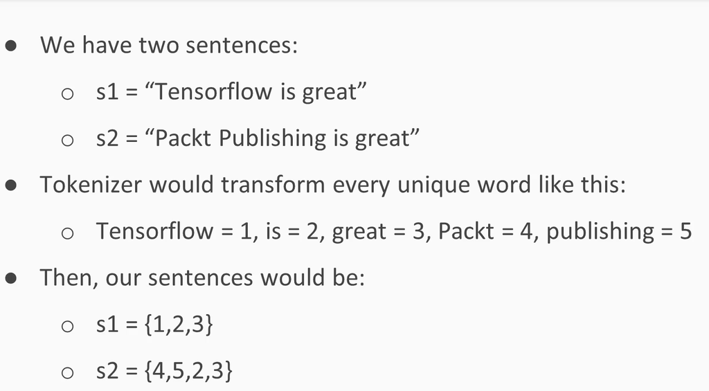

```python
max_features=5000 #we set maximum number of words to 5000
maxlen=100 #and maximum sequence length to 100
```

```python
tok = tf.keras.preprocessing.text.Tokenizer(num_words=max_features) #tokenizer step
```

```python
tok.__dict__
```

```
{'word_counts': OrderedDict(),
 'word_docs': defaultdict(int, {}),
 'filters': '!"#$%&()*+,-./:;<=>?@[\\]^_`{|}~\t\n',
 'split': ' ',
 'lower': True,
 'num_words': 5000,
 'document_count': 0,
 'char_level': False,
 'oov_token': None,
 'index_docs': defaultdict(int, {}),
 'word_index': {},
 'index_word': {}}
```

```python
list(tf_train['commentBody_no_stopwords'])[0:5]
```

```
['project makes happy 30 year times subscriber continue innovate across platforms please',
 'stunning photos reportage infuriating trump admistrations draconian reinstatement global gag order prevent men women receiving appropriate family planning advice obviously desperately needed',
 'brilliant work conception execution ive never seen anything like paper record important leave record peoples one else speaks please keep humanizing otherwise bland statistics matters time stories sounded like mine could mine see hordes people far away experiencing utter devastation empathy goes aw…
 'nyt reporters provide contributors link crowdfunding project aid organization focused specific subject news stories like every sad story biggest obvious human problems earth brbrthat regular feature dedicated clickbutton always located familiar spot 36 america truly hardened hearts toward sufferin…
 'could done print stunning']
```

```python
tok.fit_on_texts(list(tf_train['commentBody_no_stopwords'])) #fit to cleaned text
```

```python
tf_train=tok.texts_to_sequences(list(tf_train['commentBody_no_stopwords'])) #this is how we create sequences
```

```python
print(type(tf_train)) #we see that the type is now list
print(len(tf_train[1])) #we see that the number of words of the sentence is decreased to 16
tf_train[1] #and this is how our sentece looks like now, exactly a sequence of integers
```

```
<class 'list'>
16
```

```
[4916,
 3398,
 1,
 528,
 330,
 1253,
 201,
 88,
 3266,
 1682,
 138,
 1827,
 1362,
 854,
 2961,
 406]
```

```python
tf.keras.preprocessing.sequence.pad_sequences(tf_train, maxlen=maxlen)
```

```
array([[   0,    0,    0, ...,  255,  656,  273],
       [   0,    0,    0, ...,  854, 2961,  406],
       [   0,    0,    0, ..., 1289, 2034, 1118],
       ...,
       [   0,    0,    0, ...,   21,  418, 1949],
       [   0,    0,    0, ...,  172,    7, 1246],
       [   0,    0,    0, ...,  548,   56,  632]])
```

```python
tf_train=tf.keras.preprocessing.sequence.pad_sequences(tf_train, maxlen=maxlen) #let's execute pad step
```

```python
print(len(tf_train[1]))
tf_train[1] #this is how our sentece looks like after the pad step we don't have anymore 16 words but 100 (equivalent to maxlen)
```

```
100
```

```
array([   0,    0,    0,    0,    0,    0,    0,    0,    0,    0,    0,
          0,    0,    0,    0,    0,    0,    0,    0,    0,    0,    0,
          0,    0,    0,    0,    0,    0,    0,    0,    0,    0,    0,
          0,    0,    0,    0,    0,    0,    0,    0,    0,    0,    0,
          0,    0,    0,    0,    0,    0,    0,    0,    0,    0,    0,
          0,    0,    0,    0,    0,    0,    0,    0,    0,    0,    0,
          0,    0,    0,    0,    0,    0,    0,    0,    0,    0,    0,
          0,    0,    0,    0,    0,    0,    0, 4916, 3398,    1,  528,
        330, 1253,  201,   88, 3266, 1682,  138, 1827, 1362,  854, 2961,
        406])
```

```python
train['commentBody_no_stopwords'][1] #let's look at the input text
```

```
'stunning photos reportage infuriating trump admistrations draconian reinstatement global gag order prevent men women receiving appropriate family planning advice obviously desperately needed'
```

```python
tf_train = pd.DataFrame(tf_train)
```

```python
tf_train.head() #let's look at the final matrix that will use as an input for our deep learning algorithms, do you remember
#how original text looked like?
```

|  | 0 | 1 | 2 | 3 | 4 | 5 | 6 | 7 | 8 | 9 | ... | 90 | 91 | 92 | 93 | 94 | 95 | 96 | 97 | 98 | 99 |
| --- | --- | --- | --- | --- | --- | --- | --- | --- | --- | --- | --- | --- | --- | --- | --- | --- | --- | --- | --- | --- | --- |
| 0 | 0 | 0 | 0 | 0 | 0 | 0 | 0 | 0 | 0 | 0 | ... | 0 | 1797 | 181 | 586 | 915 | 148 | 66 | 255 | 656 | 273 |
| 1 | 0 | 0 | 0 | 0 | 0 | 0 | 0 | 0 | 0 | 0 | ... | 201 | 88 | 3266 | 1682 | 138 | 1827 | 1362 | 854 | 2961 | 406 |
| 2 | 0 | 0 | 0 | 0 | 0 | 0 | 0 | 0 | 0 | 0 | ... | 1788 | 402 | 146 | 565 | 2122 | 1240 | 2790 | 1289 | 2034 | 1118 |
| 3 | 0 | 0 | 0 | 0 | 0 | 0 | 0 | 0 | 0 | 0 | ... | 3766 | 78 | 2705 | 2192 | 67 | 442 | 3267 | 813 | 924 | 2791 |
| 4 | 0 | 0 | 0 | 0 | 0 | 0 | 0 | 0 | 0 | 0 | ... | 0 | 0 | 0 | 0 | 0 | 0 | 15 | 134 | 2581 | 4916 |

5 rows × 100 columns